# Cost per Download for Big 5 Providers

UVA StatLab/RDS

## Cost per Download 2017

Adding in information about the cost to UVA for each of the Big 5 providers in 2017, we can calculate the cost per download, or the package cost in dollars in 2017 divided by the number of downloads in 2017. We do this for both all 2017 downloads (JR1) and current year downloads in 2017 (JR5)

### 3a. Cost per Download, all 2017 downloads

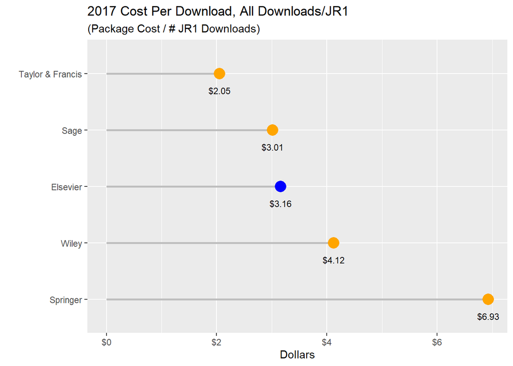

This calculation is frequently cited by vendors as “cost-per-use.” By this metric, Elsevier has a cost-per-use of $3.16. However, this may be misleading insofar as it includes back year content for which we have already purchased perpetual access.

### 3b. Cost per Download, current year 2017 downloads

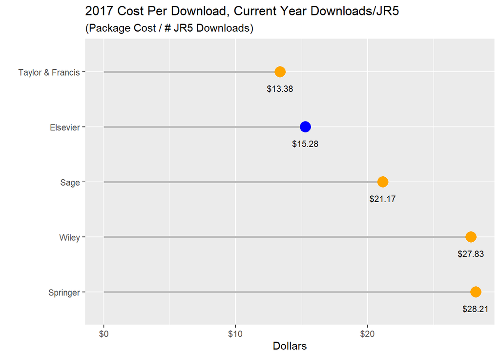

Using only current-year downloads generates a higher cost-per-use estimate. This value may be more meaningful, as it reflects only the use of new content added by the current year’s subscription.

## Elsevier Freedom versus Elsevier Subscribed

Same plots as above but with Elsevier broken down by Freedom collection and Subscribed collection. The Freedom Collection is a list of ~1850 active titles (2350 titles in all, including renamed, transferred, discontinued and forthcoming titles) that any institution subscribing to Science Direct Complete gets access to.

### 3c. Cost per Download, all 2017 downloads

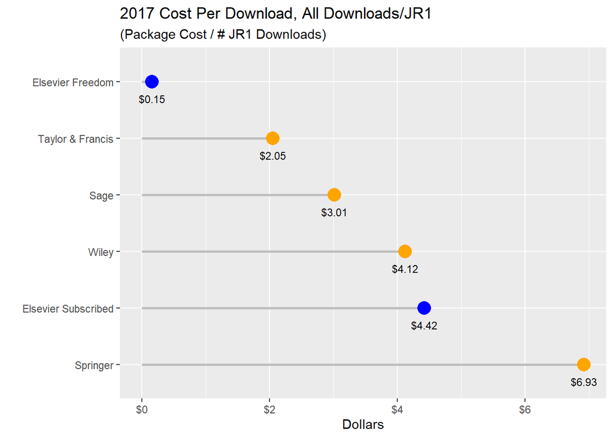

### 3d. Cost per Download, current year 2017 downloads

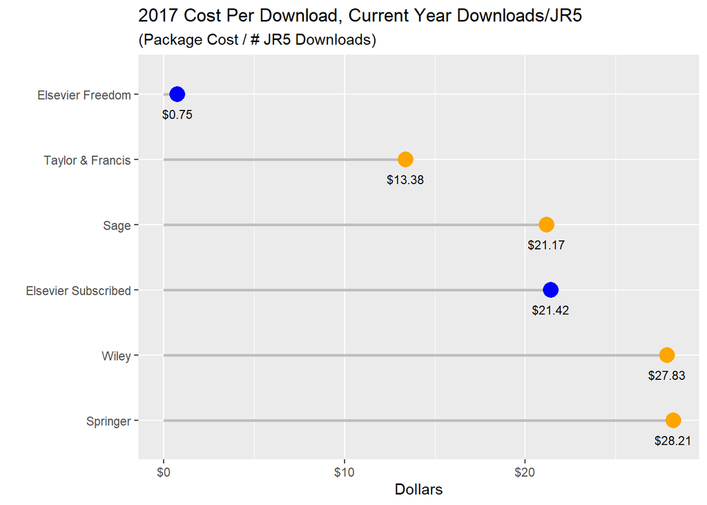

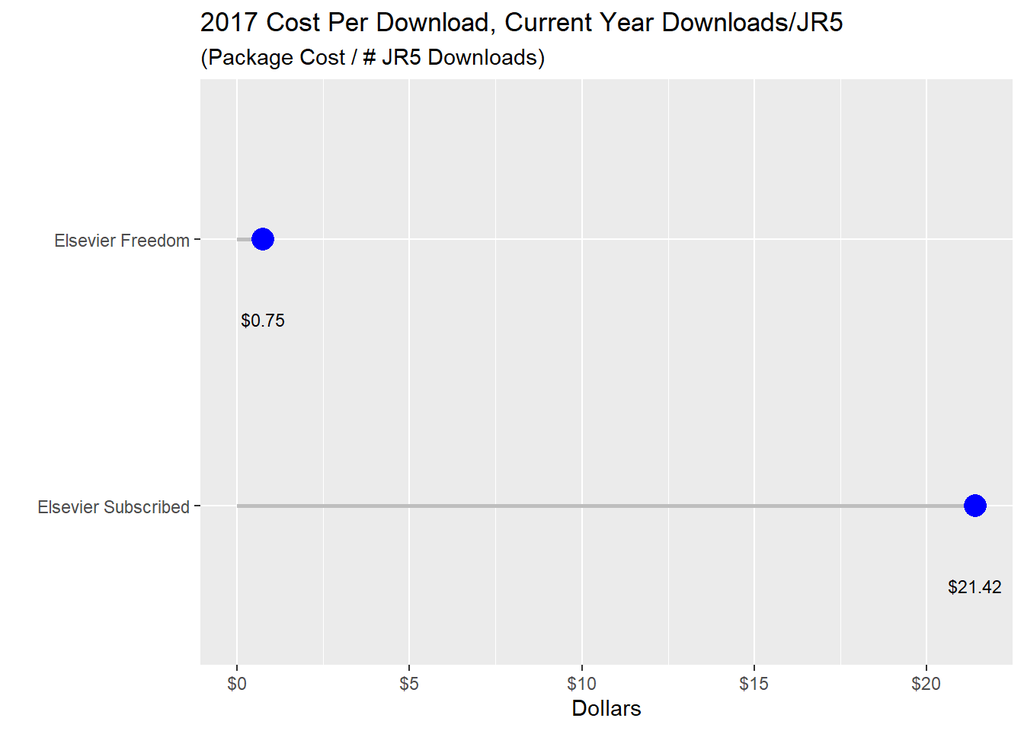